# Developing Data Products Shiny App assignment

05 maggio 2019

## Cluster Analysis with k-means Overview

This is an RStudio shiny application developed as a part of final project in the Developing Data Products course in Coursera Data Science Specialization track.

The application shows a cluster analysis with k-means and it's available at the link [clusteranalysiskmeans](https://rloprejato.shinyapps.io/clusteranalysiskmeans/). For the code you can visit the github repository [here](https://github.com/rloprejato/developingdataproducts).

This analysis is an example of clustering customers from a wholesale customer database.

You can download the data I’m using from the Berkley UCI Machine Learning Repository [here](https://archive.ics.uci.edu/ml/datasets/Wholesale+customers%5D), when you can find the data and attribute information.

## Focus on Data

Some information about data

```
##  Channel Region      Fresh             Milk          Grocery
##  1:298   1: 77   Min.   :     3   Min.   :   55   Min.   :    3
##  2:142   2: 47   1st Qu.:  3128   1st Qu.: 1533   1st Qu.: 2153
##          3:316   Median :  8504   Median : 3627   Median : 4756
##                  Mean   : 12000   Mean   : 5796   Mean   : 7951
##                  3rd Qu.: 16934   3rd Qu.: 7190   3rd Qu.:10656
##                  Max.   :112151   Max.   :73498   Max.   :92780
##      Frozen        Detergents_Paper    Delicassen
##  Min.   :   25.0   Min.   :    3.0   Min.   :    3.0
##  1st Qu.:  742.2   1st Qu.:  256.8   1st Qu.:  408.2
##  Median : 1526.0   Median :  816.5   Median :  965.5
##  Mean   : 3071.9   Mean   : 2881.5   Mean   : 1524.9
##  3rd Qu.: 3554.2   3rd Qu.: 3922.0   3rd Qu.: 1820.2
##  Max.   :60869.0   Max.   :40827.0   Max.   :47943.0
```

In the analysis we will use only the numeric variables.

## Functionality

In this app you can find:

- A graph of total Within Sum of Squares for different number of cluster (k) to help to choose the correct one
- the Number of the rows considered for the analysis
- A heatmap to help to caracterize clusters

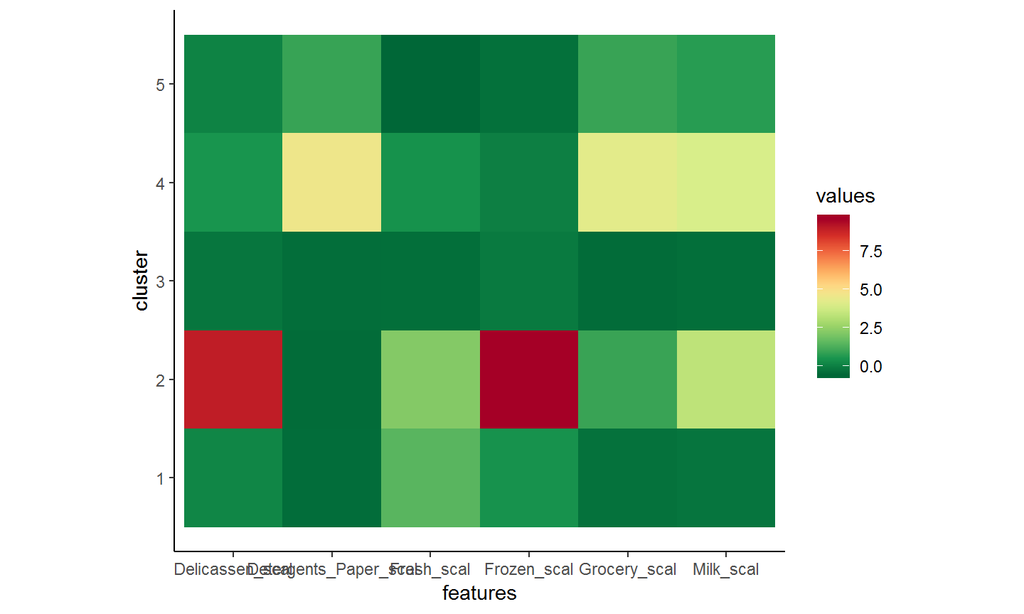

## Available Interacions

- Choose number of outliers to remove (default = 5)
- Choose interval value of k (default = from 2 to 20)
- Chooce is rescale variables (default = TRUE)
- Choose number of clusters for the heatmap (default = 5)